# PCA_Sid_Host

Veronica Radice

09/03/2021

# Principal Compoment Analysis

# *Siderastrea*

## Coral Host

### National Park color palettes

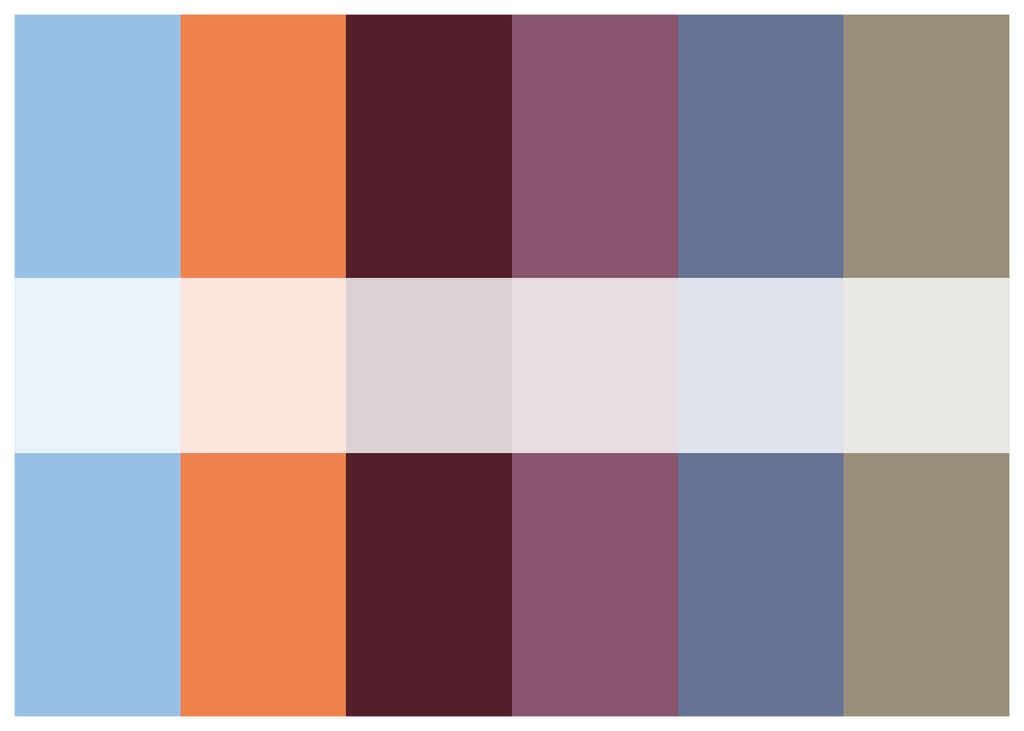

```r
# check palette
pal <- park_palette("Arches")
pal
```

```r
# select palette
chosen.palette <- palette(park_palette("Arches")) #BlueRidgePkwy
```

```r
alt.palette <- c("#8c510a", "#d8b365", "#f6e8c3", "#c7eae5", "#5ab4ac", "#01665e")
```

### Set working directory

```r
setwd("~/Documents/Rprojects/postdoc\ Rprojects/ODU_postdoc_Rprojects/Paper_Ojo_gene-expression/Siderastrea/host/")
```

## Import metadata

```r
meta <- read.csv("~/Documents/Rprojects/postdoc\ Rprojects/ODU_postdoc_Rprojects/Paper_Ojo_gene-expression/Siderastrea/Siderastrea_Year-2_metadata.csv", header=TRUE, row.names=1)

# Remove all samples that were transplanted to the Destination Ojo.Norte
# There is no control site for Norte Ojo
# For now, we are focused on samples transplanted to Laja Control or Laja Ojo sites
# This is consistent with analyses for the other 2 species in the experiment
# Also, group sample size is too small for Ojo.Norte destination

meta <- subset(meta, Destination_name != "Ojo.Norte")
```

```r
meta$Destination_type <- revalue(meta$Destination_type, c("control" = "Control", "ojo" = "Ojo"))

meta$Origin_type <- revalue(meta$Origin_type, c("Control" = "Lagoon"))

meta <- meta %>% unite(group, Origin_type, Destination_type, sep = ".", remove = FALSE)


meta[sapply(meta, is.character)] <- lapply(meta[sapply(meta, is.character)],
                                       as.factor)
# Colony_ID is equivalent to genotype
meta$Colony_ID <- as.factor(meta$Colony_ID)

meta <- meta %>% unite(colony_sample, Origin_type, Destination_type, Colony_ID, id, sep = ".", remove = FALSE)

levels(meta$group)
```

```
## [1] "Lagoon.Control" "Lagoon.Ojo"     "Ojo.Control"    "Ojo.Ojo"
## [5] "Reef.Control"   "Reef.Ojo"
```

### select relevant metadata

```r
meta <- dplyr::select(meta, Colony_ID, group, Origin_name, Origin_type, Destination_name, Destination_type, pH_Destination, colony_sample)
```

### Remove sample with >85% of null/zero counts

As in DESeq2 analysis

```r
drop <- c("R_026_N_Sid_yr2")

meta <- meta[!(row.names(meta) %in% drop),]
meta <- droplevels(meta)
dim(meta)
```

```
## [1] 38  8
```

### Remove outlier

As in DESeq2 analysis

```r
drop <- c("R_018_C_Sid_yr2")

meta <- meta[!(row.names(meta) %in% drop),]
meta <- droplevels(meta)
dim(meta)
```

```
## [1] 37  8
```

### data summary

```r
meta %>%
  group_by(group) %>%
  dplyr::summarise(count = n())
```

```
## # A tibble: 6 x 2
##   group          count
## * <fct>          <int>
## 1 Lagoon.Control     6
## 2 Lagoon.Ojo         5
## 3 Ojo.Control        5
## 4 Ojo.Ojo            6
## 5 Reef.Control       8
## 6 Reef.Ojo           7
```

# Normalized gene count data

Import normalized gene count data (from function counts(dds, normalized=TRUE)) –> Overall expression

```r
norm.genes <- readRDS(file = "counts_normalized_Sid_Host.rds")
norm.genes <- as.data.frame.array(norm.genes)
```

### Check that sample names match in both files

```r
all(colnames(norm.genes) %in% rownames(meta))
```

```
## [1] TRUE
```

```r
all(colnames(norm.genes) == rownames(meta))
```

```
## [1] TRUE
```

```r
# If your data did not match, you could use the match() function to rearrange them to be matching.
```

# Import transformed counts

```r
counts.transformed.vst <- readRDS(file = "counts_vst.BlindFalse_Sid_Host.rds")
```

# Differentially expressed genes

Import table for *each pairwise group* of Differentially Expressed gene list (pvalue < 0.05) from normalized gene count data.

```r
de.genes.LO_LC <- readRDS(file = "Sid_Host_LO_LC_pval.05.rds")
de.genes.LO_LC <- as.data.frame(de.genes.LO_LC)
dim(de.genes.LO_LC)
```

```
## [1] 233   7
```

```r
de.genes.OO_LO <- readRDS(file = "Sid_Host_OO_LO_pval.05.rds")
de.genes.OO_LO <- as.data.frame(de.genes.OO_LO)
dim(de.genes.OO_LO)
```

```
## [1] 331   7
```

```r
de.genes.LO_RO <- readRDS(file = "Sid_Host_LO_RO_pval.05.rds")
de.genes.LO_RO <- as.data.frame(de.genes.LO_RO)
dim(de.genes.LO_RO)
```

```
## [1] 1424    7
```

```r
de.genes.OO_OC <- readRDS(file = "Sid_Host_OO_OC_pval.05.rds")
de.genes.OO_OC <- as.data.frame(de.genes.OO_OC)
dim(de.genes.OO_OC)
```

```
## [1] 291   7
```

```r
de.genes.OO_RO <- readRDS(file = "Sid_Host_OO_RO_pval.05.rds")
de.genes.OO_RO <- as.data.frame(de.genes.OO_RO)
dim(de.genes.OO_RO)
```

```
## [1] 2023    7
```

```r
de.genes.RO_RC <- readRDS(file = "Sid_Host_RO_RC_pval.05.rds")
de.genes.RO_RC <- as.data.frame(de.genes.RO_RC)
dim(de.genes.RO_RC)
```

```
## [1] 1720    7
```

```r
de.genes.OC_LC <- readRDS(file = "Sid_Host_OC_LC_pval.05.rds")
de.genes.OC_LC <- as.data.frame(de.genes.OC_LC)
dim(de.genes.OC_LC)
```

```
## [1] 336   7
```

```r
de.genes.OC_RC <- readRDS(file = "Sid_Host_OC_RC_pval.05.rds")
de.genes.OC_RC <- as.data.frame(de.genes.OC_RC)
dim(de.genes.OC_RC)
```

```
## [1] 1492    7
```

```r
de.genes.LC_RC <- readRDS(file = "Sid_Host_LC_RC_pval.05.rds")
de.genes.LC_RC <- as.data.frame(de.genes.LC_RC)
dim(de.genes.LC_RC)
```

```
## [1] 1284    7
```

# Principal Component Analysis (PCA)

## Total expression

By default the function uses the top 500 most variable genes. You can change this by adding the ntop argument and specifying how many genes you want to use to draw the plot.

ntop  
- number of top genes to use for principal components, selected by highest row variance

## Total expression - by transplant treatment group

ntop = 1000

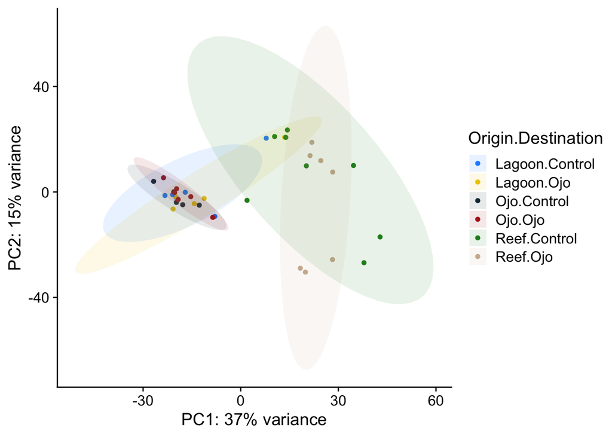

```r
# save plot
#pdf("Sid_Host_PCA_total-exp_group.pdf")

pcadata = DESeq2::plotPCA(counts.transformed.vst, intgroup = c("group"), returnData = TRUE)
percentVar = round(100 * attr(pcadata, "percentVar"))
pca = prcomp(t(assay(counts.transformed.vst)), center = TRUE, scale. = FALSE)

plot <- DESeq2::plotPCA(counts.transformed.vst, returnData = TRUE, intgroup = c("group"), ntop = 1000) %>%
      ggplot(aes(x = PC1, y = PC2)) +
      geom_point(aes(color = group), size = 1.3) +
      stat_ellipse(geom = "polygon", alpha = 1/10, aes(fill = group)) +
      scale_color_manual(values = c("dodgerblue", "gold2", "#163343", "firebrick", "forestgreen", "bisque3")) + #chosen.palette
      scale_fill_manual(values = c("dodgerblue", "gold2", "#163343", "firebrick", "forestgreen", "bisque3")) +
      xlab(paste0("PC1: ",percentVar[1],"% variance")) +
      ylab(paste0("PC2: ",percentVar[2],"% variance")) +
      labs(color = "Origin.Destination", fill = "Origin.Destination") +
      theme_cowplot()

plot
```

```r
#dev.off()

# good palette
# c("gold2", "forestgreen", "black", "firebrick", "darkorange1", "#847CA3") - favorite
# c("forestgreen", "black", "#F2D56F", "firebrick", "#F4A65E", "#847CA3")
# c("#F2D56F", "forestgreen", "black", "firebrick", "#F4A65E", "#847CA3") reordered

# Arches
# "#EC8FA3" "#FCBA65" "#FAECCF" "#8D7F99" "#8C9D57" "#163343"

# Arches reordered
# "#EC8FA3" "#FCBA65" "#163343" "#8D7F99" "#8C9D57" "#FAECCF"
# c("#EC8FA3", "#FCBA65", "#163343", "cornflowerblue", "#8C9D57", "bisque3") - favorite
# c("dodgerblue", "gold2", "#163343", "firebrick", "forestgreen", "bisque3") - new fave
# "#8C9D57" "bisque3" "#163343" "cornflowerblue" "#EC8FA3" "#FCBA65" - also good

# reordered
# c("#1A1237", "#E45A5A", "#80792B", "#F2D56F", "#F4A65E", "#847CA3")

#"#847CA3" "#E45A5A" "#F4A65E" "#80792B" "#F2D56F" "#1A1237"
```

save plot

```r
# save plot
pdf("Sid_Host_PCA_total-exp_group.pdf")

pcadata = DESeq2::plotPCA(counts.transformed.vst, intgroup = c("group"), returnData = TRUE)
percentVar = round(100 * attr(pcadata, "percentVar"))
pca = prcomp(t(assay(counts.transformed.vst)), center = TRUE, scale. = FALSE)

plot <- DESeq2::plotPCA(counts.transformed.vst, returnData = TRUE, intgroup = c("group"), ntop = 1000) %>%
      ggplot(aes(x = PC1, y = PC2)) +
      geom_point(aes(color = group), size = 1.3) +
      stat_ellipse(geom = "polygon", alpha = 1/10, aes(fill = group)) +
      scale_color_manual(values = c("dodgerblue", "gold2", "#163343", "firebrick", "forestgreen", "bisque3")) + #chosen.palette
      scale_fill_manual(values = c("dodgerblue", "gold2", "#163343", "firebrick", "forestgreen", "bisque3")) +
      xlab(paste0("PC1: ",percentVar[1],"% variance")) +
      ylab(paste0("PC2: ",percentVar[2],"% variance")) +
      labs(color = "Origin.Destination", fill = "Origin.Destination") +
      theme_cowplot()

plot
dev.off()
```

for comparison, ntop = 500 (similar)

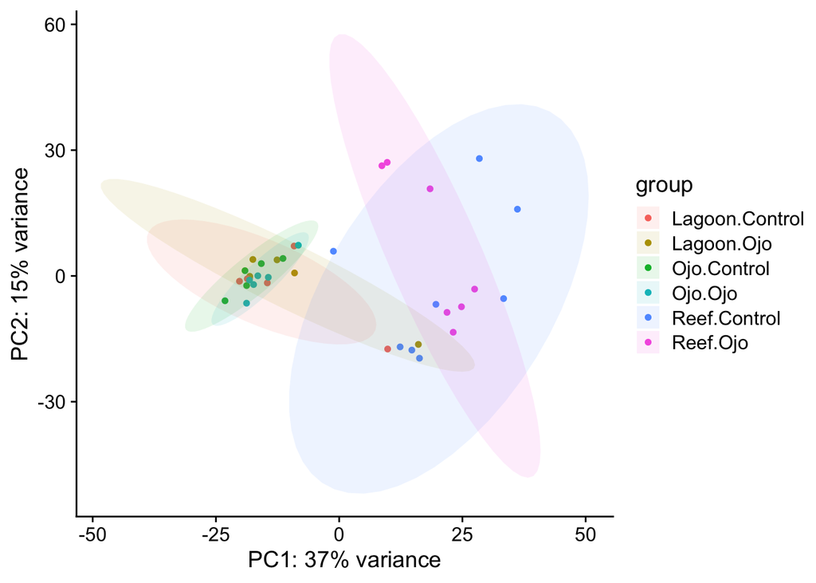

```r
pcadata = DESeq2::plotPCA(counts.transformed.vst, intgroup = c("group"), returnData = TRUE)
percentVar = round(100 * attr(pcadata, "percentVar"))
pca = prcomp(t(assay(counts.transformed.vst)), center = TRUE, scale. = FALSE)

plot <- DESeq2::plotPCA(counts.transformed.vst, returnData = TRUE, intgroup = c("group"), ntop = 500) %>%
      ggplot(aes(x = PC1, y = PC2)) +
      geom_point(aes(colour = group), size = 1.3) +
      stat_ellipse(geom = "polygon", alpha = 1/10, aes(fill = group)) +
      xlab(paste0("PC1: ",percentVar[1],"% variance")) +
      ylab(paste0("PC2: ",percentVar[2],"% variance")) +
      theme_cowplot()

plot
```

test alternate colors

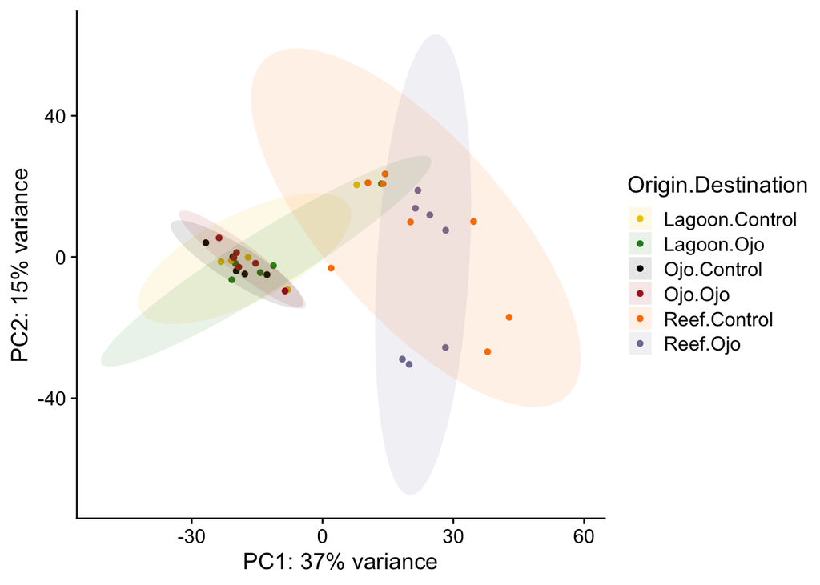

```r
pcadata = DESeq2::plotPCA(counts.transformed.vst, intgroup = c("group"), returnData = TRUE)
percentVar = round(100 * attr(pcadata, "percentVar"))
pca = prcomp(t(assay(counts.transformed.vst)), center = TRUE, scale. = FALSE)

plot <- DESeq2::plotPCA(counts.transformed.vst, returnData = TRUE, intgroup = c("group"), ntop = 1000) %>%
      ggplot(aes(x = PC1, y = PC2)) +
      geom_point(aes(color = group), size = 1.3) +
      stat_ellipse(geom = "polygon", alpha = 1/10, aes(fill = group)) +
      scale_color_manual(values = c("gold2", "forestgreen", "black", "firebrick", "darkorange1", "#847CA3")) + #chosen.palette
      scale_fill_manual(values = c("gold2", "forestgreen", "black", "firebrick", "darkorange1", "#847CA3")) +
      xlab(paste0("PC1: ",percentVar[1],"% variance")) +
      ylab(paste0("PC2: ",percentVar[2],"% variance")) +
      labs(color = "Origin.Destination", fill = "Origin.Destination") +
      theme_cowplot()

plot
```

# Total expression - Colony ID & Sample ID

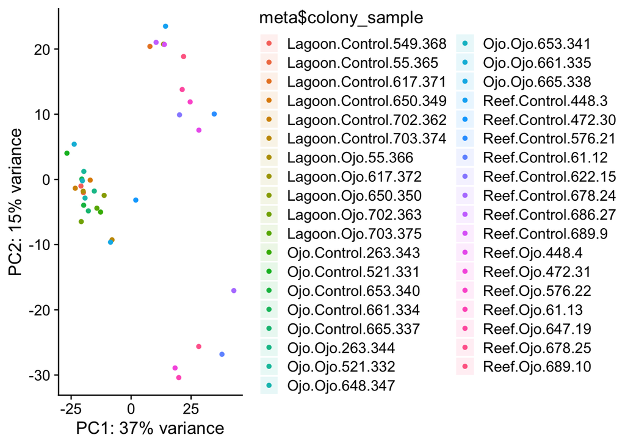

```r
pcadata = DESeq2::plotPCA(counts.transformed.vst, intgroup = c("group"), returnData = TRUE)
percentVar = round(100 * attr(pcadata, "percentVar"))
pca = prcomp(t(assay(counts.transformed.vst)), center = TRUE, scale. = FALSE)

plot <- DESeq2::plotPCA(counts.transformed.vst, returnData = TRUE, intgroup = c("group"), ntop = 1000) %>%
      ggplot(aes(x = PC1, y = PC2)) +
      geom_point(aes(color = meta$colony_sample), size = 1.3) +
      stat_ellipse(geom = "polygon", alpha = 1/10, aes(fill = meta$colony_sample)) +
      xlab(paste0("PC1: ",percentVar[1],"% variance")) +
      ylab(paste0("PC2: ",percentVar[2],"% variance")) +
      theme_cowplot()

plot
```

# Total expression - Origin

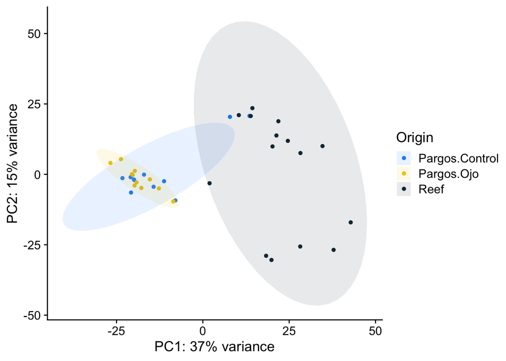

```r
pcadata = DESeq2::plotPCA(counts.transformed.vst, intgroup = c("Origin_name"), returnData = TRUE)
percentVar = round(100 * attr(pcadata, "percentVar"))
pca = prcomp(t(assay(counts.transformed.vst)), center = TRUE, scale. = FALSE)

plot <- DESeq2::plotPCA(counts.transformed.vst, returnData = TRUE, intgroup = c("Origin_name"), ntop = 1000) %>%
      ggplot(aes(x = PC1, y = PC2)) +
      geom_point(aes(color = Origin_name), size = 1.3) +
      stat_ellipse(geom = "polygon", alpha = 1/10, aes(fill = Origin_name)) +
      scale_color_manual(values = c("dodgerblue", "gold2", "#163343", "firebrick", "forestgreen", "bisque3")) + #chosen.palette
      scale_fill_manual(values = c("dodgerblue", "gold2", "#163343", "firebrick", "forestgreen", "bisque3")) +
      xlab(paste0("PC1: ",percentVar[1],"% variance")) +
      ylab(paste0("PC2: ",percentVar[2],"% variance")) +
      labs(color = "Origin", fill = "Origin") +
      theme_cowplot()

plot
```

# Total expression - Destination: Ojo vs. Control

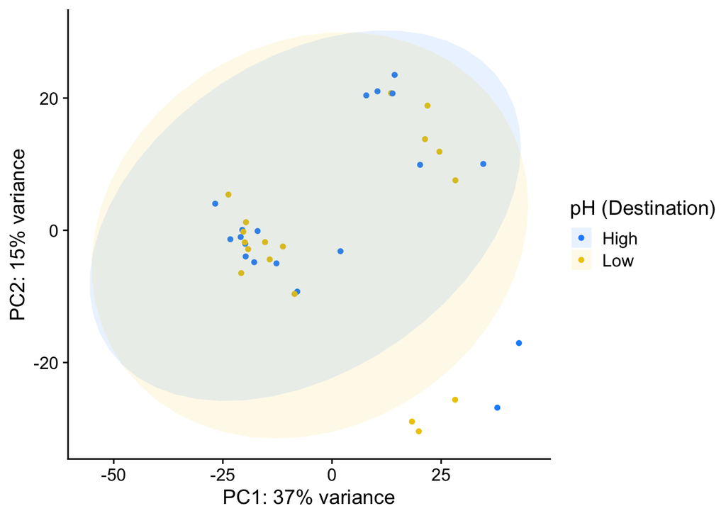

```r
pcadata = DESeq2::plotPCA(counts.transformed.vst, intgroup = c("pH_Destination"), returnData = TRUE)
percentVar = round(100 * attr(pcadata, "percentVar"))
pca = prcomp(t(assay(counts.transformed.vst)), center = TRUE, scale. = FALSE)

plot <- DESeq2::plotPCA(counts.transformed.vst, returnData = TRUE, intgroup = c("pH_Destination"), ntop = 1000) %>%
      ggplot(aes(x = PC1, y = PC2)) +
      geom_point(aes(color = pH_Destination), size = 1.3) +
      stat_ellipse(geom = "polygon", alpha = 1/10, aes(fill = pH_Destination)) +
      scale_color_manual(values = c("dodgerblue", "gold2", "#163343", "firebrick", "forestgreen", "bisque3")) + #chosen.palette
      scale_fill_manual(values = c("dodgerblue", "gold2", "#163343", "firebrick", "forestgreen", "bisque3")) +
      xlab(paste0("PC1: ",percentVar[1],"% variance")) +
      ylab(paste0("PC2: ",percentVar[2],"% variance")) +
      labs(color = "pH (Destination)", fill = "pH (Destination)") +
      theme_cowplot()

plot
```

# Total expression - Colony (genotype)

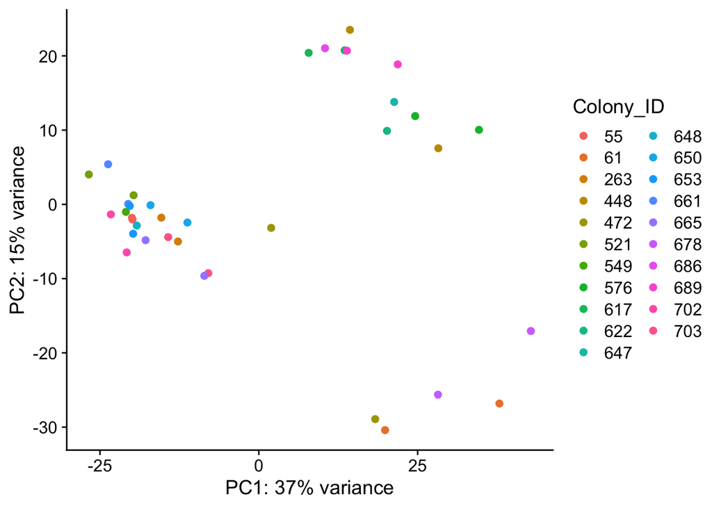

```r
pcadata = DESeq2::plotPCA(counts.transformed.vst, intgroup = c("Colony_ID"), returnData = TRUE)
percentVar = round(100 * attr(pcadata, "percentVar"))
pca = prcomp(t(assay(counts.transformed.vst)), center = TRUE, scale. = FALSE)

plot <- DESeq2::plotPCA(counts.transformed.vst, returnData = TRUE, intgroup = c("Colony_ID"), ntop = 1000) %>%
      ggplot(aes(x = PC1, y = PC2)) +
      geom_point(aes(colour = Colony_ID), size = 2) +
      xlab(paste0("PC1: ",percentVar[1],"% variance")) +
      ylab(paste0("PC2: ",percentVar[2],"% variance")) +
      labs(color = "Colony_ID", fill = "Colony_ID") +
      theme_cowplot()

plot
```

# Principal Component Analysis (PCA)

## Pairwise group contrasts

Significantly different genes (pvalue < 0.05) between treatment groups for pairwise comparisons

### PCA - All indiv. - LO_RO

```r
# extract row names from DE gene list
rownames(de.genes.LO_RO) <- de.genes.LO_RO[,1]

sigChanges <- rownames(de.genes.LO_RO)[de.genes.LO_RO$pvalue < 0.05 & !is.na(de.genes.LO_RO$pvalue)]

counts_de <- counts.transformed.vst[rownames(counts.transformed.vst) %in% sigChanges,]

dim(counts_de)
```

```
## [1] 1424   37
```

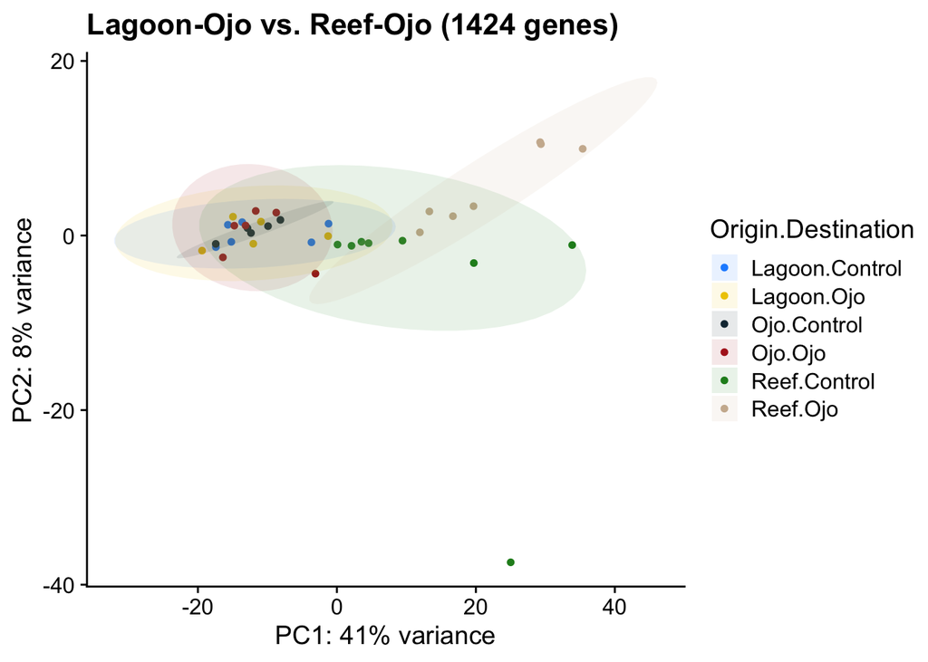

```r
pcadata = DESeq2::plotPCA(counts_de, intgroup = c("group"), returnData = TRUE)
percentVar = round(100 * attr(pcadata, "percentVar"))
pca = prcomp(t(assay(counts_de)), center = TRUE, scale. = FALSE)

plot <- DESeq2::plotPCA(counts_de, returnData = TRUE, intgroup = c("group")) %>%
      ggplot(aes(x = PC1, y = PC2)) +
      geom_point(aes(color = group), size = 1.3) +
      stat_ellipse(geom = "polygon", alpha = 1/10, aes(fill = group)) +
      scale_color_manual(values = c("dodgerblue", "gold2", "#163343", "firebrick", "forestgreen", "bisque3")) + #chosen.palette
      scale_fill_manual(values = c("dodgerblue", "gold2", "#163343", "firebrick", "forestgreen", "bisque3")) +
      xlab(paste0("PC1: ",percentVar[1],"% variance")) +
      ylab(paste0("PC2: ",percentVar[2],"% variance")) +
      labs(title = "Lagoon-Ojo vs. Reef-Ojo (1424 genes)") +
      labs(color = "Origin.Destination", fill = "Origin.Destination") +
      theme_cowplot()

plot
```

save plot

```r
# save plot
pdf("Sid_Host_PCA_LO_RO_all-indiv.pdf")

pcadata = DESeq2::plotPCA(counts_de, intgroup = c("group"), returnData = TRUE)
percentVar = round(100 * attr(pcadata, "percentVar"))
pca = prcomp(t(assay(counts_de)), center = TRUE, scale. = FALSE)

plot <- DESeq2::plotPCA(counts_de, returnData = TRUE, intgroup = c("group")) %>%
      ggplot(aes(x = PC1, y = PC2)) +
      geom_point(aes(color = group), size = 1.3) +
      stat_ellipse(geom = "polygon", alpha = 1/10, aes(fill = group)) +
      scale_color_manual(values = c("dodgerblue", "gold2", "#163343", "firebrick", "forestgreen", "bisque3")) + #chosen.palette
      scale_fill_manual(values = c("dodgerblue", "gold2", "#163343", "firebrick", "forestgreen", "bisque3")) +
      xlab(paste0("PC1: ",percentVar[1],"% variance")) +
      ylab(paste0("PC2: ",percentVar[2],"% variance")) +
      labs(title = "Lagoon-Ojo vs. Reef-Ojo (1424 genes)") +
      labs(color = "Origin.Destination", fill = "Origin.Destination") +
      theme_cowplot()

plot
dev.off()
```

### PCA - Subset indiv. - LO_RO

```r
# extract row names from DE gene list
rownames(de.genes.LO_RO) <- de.genes.LO_RO[,1]

sigChanges <- rownames(de.genes.LO_RO)[de.genes.LO_RO$pvalue < 0.05 & !is.na(de.genes.LO_RO$pvalue)]

# select relevant sample columns for the given pairwise comparison
colnames(counts.transformed.vst)
```

```
##  [1] "PC_349_C_Sid_yr2"  "PC_350_La_Sid_yr2" "PC_362_C_Sid_yr2"
##  [4] "PC_363_La_Sid_yr2" "PC_365_C_Sid_yr2"  "PC_366_La_Sid_yr2"
##  [7] "PC_368_C_Sid_yr2"  "PC_371_C_Sid_yr2"  "PC_372_La_Sid_yr2"
## [10] "PC_374_C_Sid_yr2"  "PC_375_La_Sid_yr2" "PO_331_C_Sid_yr2"
## [13] "PO_332_La_Sid_yr2" "PO_334_C_Sid_yr2"  "PO_335_La_Sid_yr2"
## [16] "PO_337_C_Sid_yr2"  "PO_338_La_Sid_yr2" "PO_340_C_Sid_yr2"
## [19] "PO_341_La_Sid_yr2" "PO_343_C_Sid_yr2"  "PO_344_La_Sid_yr2"
## [22] "PO_347_La_Sid_yr2" "R_003_C_Sid_yr2"   "R_004_La_Sid_yr2"
## [25] "R_009_C_Sid_yr2"   "R_010_La_Sid_yr2"  "R_012_C_Sid_yr2"
## [28] "R_013_La_Sid_yr2"  "R_015_C_Sid_yr2"   "R_019_La_Sid_yr2"
## [31] "R_021_C_Sid_yr2"   "R_022_La_Sid_yr2"  "R_024_C_Sid_yr2"
## [34] "R_025_La_Sid_yr2"  "R_027_C_Sid_yr2"   "R_030_C_Sid_yr2"
## [37] "R_031_La_Sid_yr2"
```

```r
counts_de <- counts.transformed.vst[,c(2,4,6,9,11,24,26,28,30,32,34,37)]
counts_de <- counts_de[rownames(counts_de) %in% sigChanges,]

dim(counts_de)
```

```
## [1] 1424   12
```

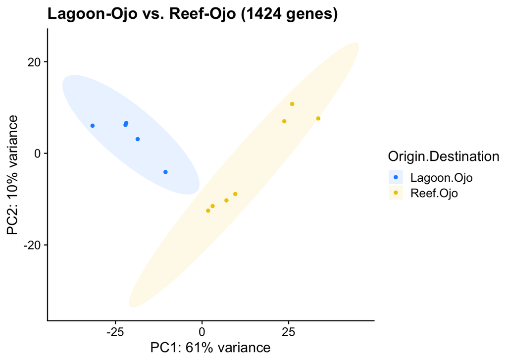

```r
# save plot
#pdf("Sid_Host_PCA_LO_RO_subset.pdf")

pcadata = DESeq2::plotPCA(counts_de, intgroup = c("group"), returnData = TRUE)
percentVar = round(100 * attr(pcadata, "percentVar"))
pca = prcomp(t(assay(counts_de)), center = TRUE, scale. = FALSE)

plot <- DESeq2::plotPCA(counts_de, returnData = TRUE, intgroup = c("group")) %>%
      ggplot(aes(x = PC1, y = PC2)) +
      geom_point(aes(color = group), size = 1.3) +
      stat_ellipse(geom = "polygon", alpha = 1/10, aes(fill = group)) +
      scale_color_manual(values = c("dodgerblue", "gold2", "#163343", "firebrick", "forestgreen", "bisque3")) + #chosen.palette
      scale_fill_manual(values = c("dodgerblue", "gold2", "#163343", "firebrick", "forestgreen", "bisque3")) +
      xlab(paste0("PC1: ",percentVar[1],"% variance")) +
      ylab(paste0("PC2: ",percentVar[2],"% variance")) +
      labs(title = "Lagoon-Ojo vs. Reef-Ojo (1424 genes)") +
      labs(color = "Origin.Destination", fill = "Origin.Destination") +
      theme_cowplot()

plot
```

```r
#dev.off()
```

check

```r
dim(counts_de)
```

```
## [1] 1424   12
```

```r
dim(de.genes.LO_RO)
```

```
## [1] 1424    7
```

```r
colnames(counts_de)
```

```
##  [1] "PC_350_La_Sid_yr2" "PC_363_La_Sid_yr2" "PC_366_La_Sid_yr2"
##  [4] "PC_372_La_Sid_yr2" "PC_375_La_Sid_yr2" "R_004_La_Sid_yr2"
##  [7] "R_010_La_Sid_yr2"  "R_013_La_Sid_yr2"  "R_019_La_Sid_yr2"
## [10] "R_022_La_Sid_yr2"  "R_025_La_Sid_yr2"  "R_031_La_Sid_yr2"
```

## PCA - all indiv. - OO_RO

```r
# extract row names from DE gene list
rownames(de.genes.OO_RO) <- de.genes.OO_RO[,1]

sigChanges <- rownames(de.genes.OO_RO)[de.genes.OO_RO$pvalue < 0.05 & !is.na(de.genes.OO_RO$pvalue)]

counts_de <- counts.transformed.vst[rownames(counts.transformed.vst) %in% sigChanges,]

dim(counts_de)
```

```
## [1] 2023   37
```

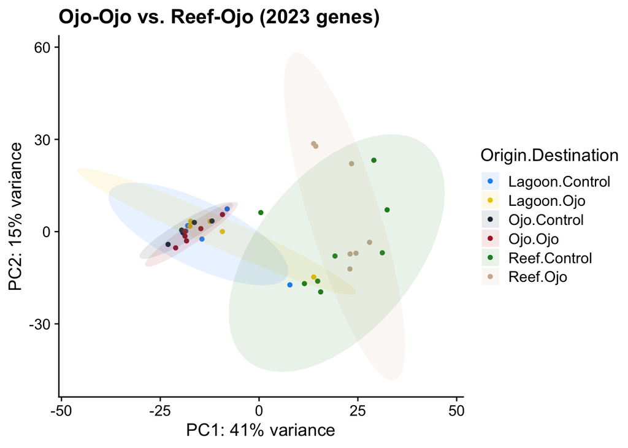

```r
pcadata = DESeq2::plotPCA(counts_de, intgroup = c("group"), returnData = TRUE)
percentVar = round(100 * attr(pcadata, "percentVar"))
pca = prcomp(t(assay(counts_de)), center = TRUE, scale. = FALSE)

plot <- DESeq2::plotPCA(counts_de, returnData = TRUE, intgroup = c("group")) %>%
      ggplot(aes(x = PC1, y = PC2)) +
      geom_point(aes(color = group), size = 1.3) +
      stat_ellipse(geom = "polygon", alpha = 1/10, aes(fill = group)) +
      scale_color_manual(values = c("dodgerblue", "gold2", "#163343", "firebrick", "forestgreen", "bisque3")) + #chosen.palette
      scale_fill_manual(values = c("dodgerblue", "gold2", "#163343", "firebrick", "forestgreen", "bisque3")) +
      xlab(paste0("PC1: ",percentVar[1],"% variance")) +
      ylab(paste0("PC2: ",percentVar[2],"% variance")) +
      labs(title = "Ojo-Ojo vs. Reef-Ojo (2023 genes)") +
      labs(color = "Origin.Destination", fill = "Origin.Destination") +
      theme_cowplot()

plot
```

save plot

```r
# save plot
pdf("Sid_Host_PCA_OO_RO_all-indiv.pdf")

pcadata = DESeq2::plotPCA(counts_de, intgroup = c("group"), returnData = TRUE)
percentVar = round(100 * attr(pcadata, "percentVar"))
pca = prcomp(t(assay(counts_de)), center = TRUE, scale. = FALSE)

plot <- DESeq2::plotPCA(counts_de, returnData = TRUE, intgroup = c("group")) %>%
      ggplot(aes(x = PC1, y = PC2)) +
      geom_point(aes(color = group), size = 1.3) +
      stat_ellipse(geom = "polygon", alpha = 1/10, aes(fill = group)) +
      scale_color_manual(values = c("dodgerblue", "gold2", "#163343", "firebrick", "forestgreen", "bisque3")) + #chosen.palette
      scale_fill_manual(values = c("dodgerblue", "gold2", "#163343", "firebrick", "forestgreen", "bisque3")) +
      xlab(paste0("PC1: ",percentVar[1],"% variance")) +
      ylab(paste0("PC2: ",percentVar[2],"% variance")) +
      labs(title = "Ojo-Ojo vs. Reef-Ojo (2023 genes)") +
      labs(color = "Origin.Destination", fill = "Origin.Destination") +
      theme_cowplot()

plot
dev.off()
```

## PCA - subset indiv. - OO_RO

```r
# extract row names from DE gene list
rownames(de.genes.OO_RO) <- de.genes.OO_RO[,1]

sigChanges <- rownames(de.genes.OO_RO)[de.genes.OO_RO$pvalue < 0.05 & !is.na(de.genes.OO_RO$pvalue)]

# select relevant sample columns for the given pairwise comparison
colnames(counts.transformed.vst)
```

```
##  [1] "PC_349_C_Sid_yr2"  "PC_350_La_Sid_yr2" "PC_362_C_Sid_yr2"
##  [4] "PC_363_La_Sid_yr2" "PC_365_C_Sid_yr2"  "PC_366_La_Sid_yr2"
##  [7] "PC_368_C_Sid_yr2"  "PC_371_C_Sid_yr2"  "PC_372_La_Sid_yr2"
## [10] "PC_374_C_Sid_yr2"  "PC_375_La_Sid_yr2" "PO_331_C_Sid_yr2"
## [13] "PO_332_La_Sid_yr2" "PO_334_C_Sid_yr2"  "PO_335_La_Sid_yr2"
## [16] "PO_337_C_Sid_yr2"  "PO_338_La_Sid_yr2" "PO_340_C_Sid_yr2"
## [19] "PO_341_La_Sid_yr2" "PO_343_C_Sid_yr2"  "PO_344_La_Sid_yr2"
## [22] "PO_347_La_Sid_yr2" "R_003_C_Sid_yr2"   "R_004_La_Sid_yr2"
## [25] "R_009_C_Sid_yr2"   "R_010_La_Sid_yr2"  "R_012_C_Sid_yr2"
## [28] "R_013_La_Sid_yr2"  "R_015_C_Sid_yr2"   "R_019_La_Sid_yr2"
## [31] "R_021_C_Sid_yr2"   "R_022_La_Sid_yr2"  "R_024_C_Sid_yr2"
## [34] "R_025_La_Sid_yr2"  "R_027_C_Sid_yr2"   "R_030_C_Sid_yr2"
## [37] "R_031_La_Sid_yr2"
```

```r
counts_de <- counts.transformed.vst[,c(13,15,17,19,21,22,24,26,28,30,32,34,37)]

counts_de <- counts_de[rownames(counts.transformed.vst) %in% sigChanges,]

dim(counts_de)
```

```
## [1] 2023   13
```

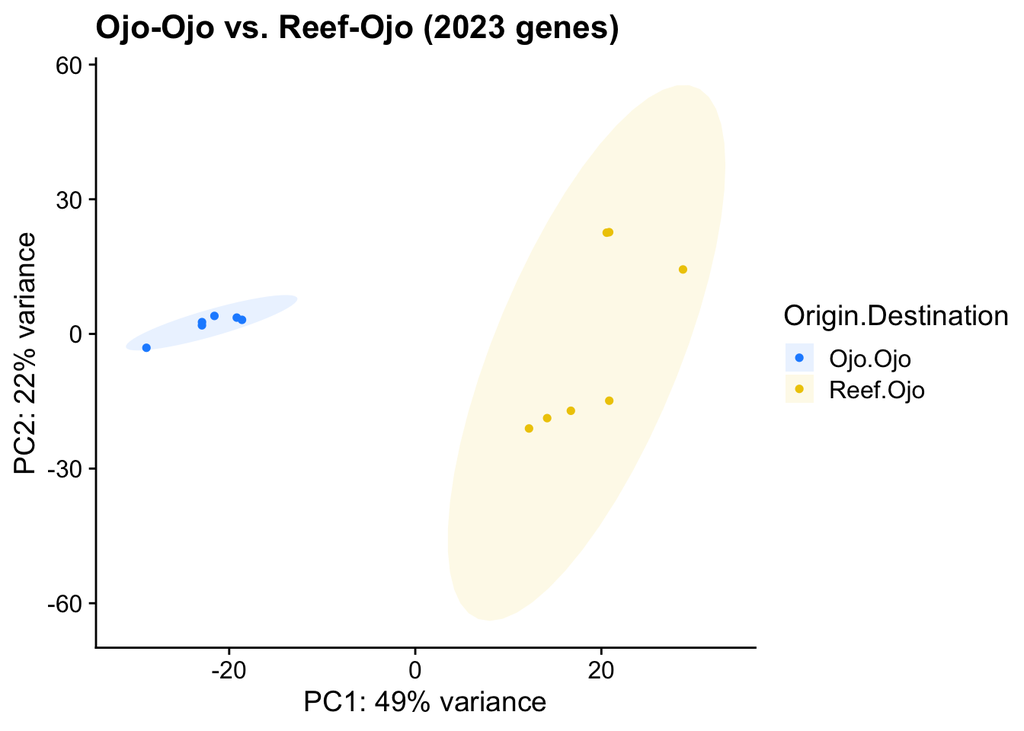

```r
# save plot
#pdf("Sid_Host_PCA_OO_RO_subset.pdf")

pcadata = DESeq2::plotPCA(counts_de, intgroup = c("group"), returnData = TRUE)
percentVar = round(100 * attr(pcadata, "percentVar"))
pca = prcomp(t(assay(counts_de)), center = TRUE, scale. = FALSE)

plot <- DESeq2::plotPCA(counts_de, returnData = TRUE, intgroup = c("group")) %>%
      ggplot(aes(x = PC1, y = PC2)) +
      geom_point(aes(color = group), size = 1.3) +
      stat_ellipse(geom = "polygon", alpha = 1/10, aes(fill = group)) +
      scale_color_manual(values = c("dodgerblue", "gold2", "#163343", "firebrick", "forestgreen", "bisque3")) + #chosen.palette
      scale_fill_manual(values = c("dodgerblue", "gold2", "#163343", "firebrick", "forestgreen", "bisque3")) +
      xlab(paste0("PC1: ",percentVar[1],"% variance")) +
      ylab(paste0("PC2: ",percentVar[2],"% variance")) +
      labs(title = "Ojo-Ojo vs. Reef-Ojo (2023 genes)") +
      labs(color = "Origin.Destination", fill = "Origin.Destination") +
      theme_cowplot()

plot
```

```r
#dev.off()
```

check

```r
dim(counts_de)
```

```
## [1] 2023   13
```

```r
dim(de.genes.OO_RO)
```

```
## [1] 2023    7
```

```r
colnames(counts_de)
```

```
##  [1] "PO_332_La_Sid_yr2" "PO_335_La_Sid_yr2" "PO_338_La_Sid_yr2"
##  [4] "PO_341_La_Sid_yr2" "PO_344_La_Sid_yr2" "PO_347_La_Sid_yr2"
##  [7] "R_004_La_Sid_yr2"  "R_010_La_Sid_yr2"  "R_013_La_Sid_yr2"
## [10] "R_019_La_Sid_yr2"  "R_022_La_Sid_yr2"  "R_025_La_Sid_yr2"
## [13] "R_031_La_Sid_yr2"
```

## PCA - all indiv. - RO_RC

```r
# extract row names from DE gene list
rownames(de.genes.RO_RC) <- de.genes.RO_RC[,1]

sigChanges <- rownames(de.genes.RO_RC)[de.genes.RO_RC$pvalue < 0.05 & !is.na(de.genes.RO_RC$pvalue)]

counts_de <- counts.transformed.vst[rownames(counts.transformed.vst) %in% sigChanges,]

dim(counts_de)
```

```
## [1] 1720   37
```

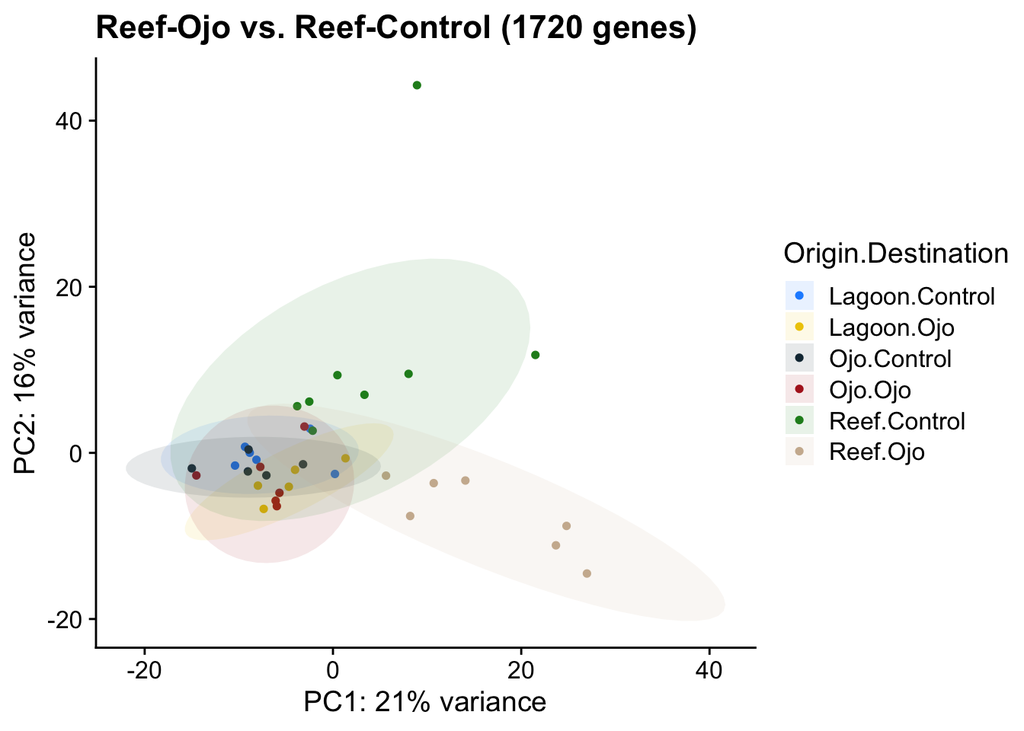

```r
pcadata = DESeq2::plotPCA(counts_de, intgroup = c("group"), returnData = TRUE)
percentVar = round(100 * attr(pcadata, "percentVar"))
pca = prcomp(t(assay(counts_de)), center = TRUE, scale. = FALSE)

plot <- DESeq2::plotPCA(counts_de, returnData = TRUE, intgroup = c("group")) %>%
      ggplot(aes(x = PC1, y = PC2)) +
      geom_point(aes(color = group), size = 1.3) +
      stat_ellipse(geom = "polygon", alpha = 1/10, aes(fill = group)) +
      scale_color_manual(values = c("dodgerblue", "gold2", "#163343", "firebrick", "forestgreen", "bisque3")) + #chosen.palette
      scale_fill_manual(values = c("dodgerblue", "gold2", "#163343", "firebrick", "forestgreen", "bisque3")) +
      xlab(paste0("PC1: ",percentVar[1],"% variance")) +
      ylab(paste0("PC2: ",percentVar[2],"% variance")) +
      labs(title = "Reef-Ojo vs. Reef-Control (1720 genes)") +
      labs(color = "Origin.Destination", fill = "Origin.Destination") +
      theme_cowplot()

plot
```

save plot

```r
# save plot
pdf("Sid_Host_PCA_RO_RC_all-indiv.pdf")

pcadata = DESeq2::plotPCA(counts_de, intgroup = c("group"), returnData = TRUE)
percentVar = round(100 * attr(pcadata, "percentVar"))
pca = prcomp(t(assay(counts_de)), center = TRUE, scale. = FALSE)

plot <- DESeq2::plotPCA(counts_de, returnData = TRUE, intgroup = c("group")) %>%
      ggplot(aes(x = PC1, y = PC2)) +
      geom_point(aes(color = group), size = 1.3) +
      stat_ellipse(geom = "polygon", alpha = 1/10, aes(fill = group)) +
      scale_color_manual(values = c("dodgerblue", "gold2", "#163343", "firebrick", "forestgreen", "bisque3")) + #chosen.palette
      scale_fill_manual(values = c("dodgerblue", "gold2", "#163343", "firebrick", "forestgreen", "bisque3")) +
      xlab(paste0("PC1: ",percentVar[1],"% variance")) +
      ylab(paste0("PC2: ",percentVar[2],"% variance")) +
      labs(title = "Reef-Ojo vs. Reef-Control (1720 genes)") +
      labs(color = "Origin.Destination", fill = "Origin.Destination") +
      theme_cowplot()

plot
dev.off()
```

## PCA - subset indiv. - RO_RC

```r
# extract row names from DE gene list
rownames(de.genes.RO_RC) <- de.genes.RO_RC[,1]

sigChanges <- rownames(de.genes.RO_RC)[de.genes.RO_RC$pvalue < 0.05 & !is.na(de.genes.RO_RC$pvalue)]

# select relevant sample columns for the given pairwise comparison
colnames(counts.transformed.vst)
```

```
##  [1] "PC_349_C_Sid_yr2"  "PC_350_La_Sid_yr2" "PC_362_C_Sid_yr2"
##  [4] "PC_363_La_Sid_yr2" "PC_365_C_Sid_yr2"  "PC_366_La_Sid_yr2"
##  [7] "PC_368_C_Sid_yr2"  "PC_371_C_Sid_yr2"  "PC_372_La_Sid_yr2"
## [10] "PC_374_C_Sid_yr2"  "PC_375_La_Sid_yr2" "PO_331_C_Sid_yr2"
## [13] "PO_332_La_Sid_yr2" "PO_334_C_Sid_yr2"  "PO_335_La_Sid_yr2"
## [16] "PO_337_C_Sid_yr2"  "PO_338_La_Sid_yr2" "PO_340_C_Sid_yr2"
## [19] "PO_341_La_Sid_yr2" "PO_343_C_Sid_yr2"  "PO_344_La_Sid_yr2"
## [22] "PO_347_La_Sid_yr2" "R_003_C_Sid_yr2"   "R_004_La_Sid_yr2"
## [25] "R_009_C_Sid_yr2"   "R_010_La_Sid_yr2"  "R_012_C_Sid_yr2"
## [28] "R_013_La_Sid_yr2"  "R_015_C_Sid_yr2"   "R_019_La_Sid_yr2"
## [31] "R_021_C_Sid_yr2"   "R_022_La_Sid_yr2"  "R_024_C_Sid_yr2"
## [34] "R_025_La_Sid_yr2"  "R_027_C_Sid_yr2"   "R_030_C_Sid_yr2"
## [37] "R_031_La_Sid_yr2"
```

```r
counts_de <- counts.transformed.vst[,c(23:37)]

counts_de <- counts_de[rownames(counts.transformed.vst) %in% sigChanges,]

dim(counts_de)
```

```
## [1] 1720   15
```

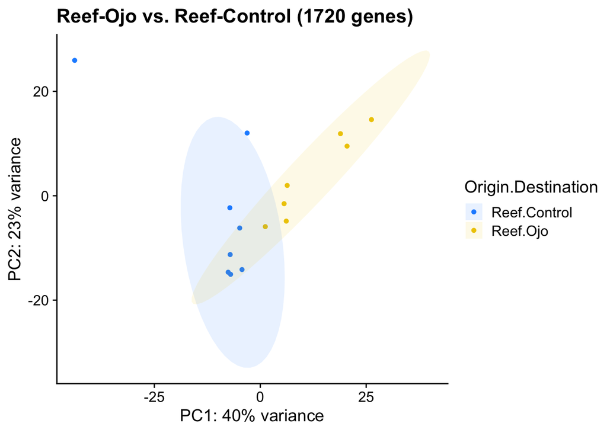

```r
# save plot
#pdf("Sid_Host_PCA_RO_RC_subset.pdf")

pcadata = DESeq2::plotPCA(counts_de, intgroup = c("group"), returnData = TRUE)
percentVar = round(100 * attr(pcadata, "percentVar"))
pca = prcomp(t(assay(counts_de)), center = TRUE, scale. = FALSE)

plot <- DESeq2::plotPCA(counts_de, returnData = TRUE, intgroup = c("group")) %>%
      ggplot(aes(x = PC1, y = PC2)) +
      geom_point(aes(color = group), size = 1.3) +
      stat_ellipse(geom = "polygon", alpha = 1/10, aes(fill = group)) +
      scale_color_manual(values = c("dodgerblue", "gold2", "#163343", "firebrick", "forestgreen", "bisque3")) + #chosen.palette
      scale_fill_manual(values = c("dodgerblue", "gold2", "#163343", "firebrick", "forestgreen", "bisque3")) +
      xlab(paste0("PC1: ",percentVar[1],"% variance")) +
      ylab(paste0("PC2: ",percentVar[2],"% variance")) +
      labs(title = "Reef-Ojo vs. Reef-Control (1720 genes)") +
      labs(color = "Origin.Destination", fill = "Origin.Destination") +
      theme_cowplot()

plot
```

```r
#dev.off()
```

check

```r
dim(counts_de)
```

```
## [1] 1720   15
```

```r
dim(de.genes.RO_RC)
```

```
## [1] 1720    7
```

```r
colnames(counts_de)
```

```
##  [1] "R_003_C_Sid_yr2"  "R_004_La_Sid_yr2" "R_009_C_Sid_yr2"  "R_010_La_Sid_yr2"
##  [5] "R_012_C_Sid_yr2"  "R_013_La_Sid_yr2" "R_015_C_Sid_yr2"  "R_019_La_Sid_yr2"
##  [9] "R_021_C_Sid_yr2"  "R_022_La_Sid_yr2" "R_024_C_Sid_yr2"  "R_025_La_Sid_yr2"
## [13] "R_027_C_Sid_yr2"  "R_030_C_Sid_yr2"  "R_031_La_Sid_yr2"
```

## PCA - all indiv. - LC_RC

```r
# extract row names from DE gene list
rownames(de.genes.LC_RC) <- de.genes.LC_RC[,1]

sigChanges <- rownames(de.genes.LC_RC)[de.genes.LC_RC$pvalue < 0.05 & !is.na(de.genes.LC_RC$pvalue)]

counts_de <- counts.transformed.vst[rownames(counts.transformed.vst) %in% sigChanges,]

dim(counts_de)
```

```
## [1] 1284   37
```

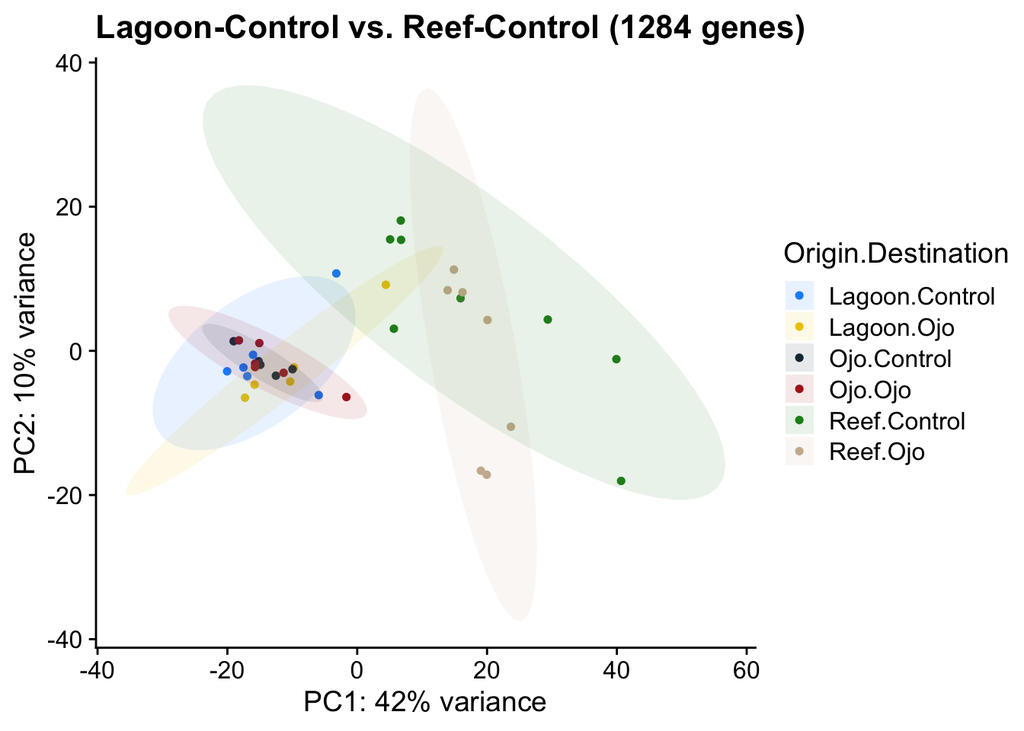

```r
pcadata = DESeq2::plotPCA(counts_de, intgroup = c("group"), returnData = TRUE)
percentVar = round(100 * attr(pcadata, "percentVar"))
pca = prcomp(t(assay(counts_de)), center = TRUE, scale. = FALSE)

plot <- DESeq2::plotPCA(counts_de, returnData = TRUE, intgroup = c("group")) %>%
      ggplot(aes(x = PC1, y = PC2)) +
      geom_point(aes(color = group), size = 1.3) +
      stat_ellipse(geom = "polygon", alpha = 1/10, aes(fill = group)) +
      scale_color_manual(values = c("dodgerblue", "gold2", "#163343", "firebrick", "forestgreen", "bisque3")) + #chosen.palette
      scale_fill_manual(values = c("dodgerblue", "gold2", "#163343", "firebrick", "forestgreen", "bisque3")) +
      xlab(paste0("PC1: ",percentVar[1],"% variance")) +
      ylab(paste0("PC2: ",percentVar[2],"% variance")) +
      labs(title = "Lagoon-Control vs. Reef-Control (1284 genes)") +
      labs(color = "Origin.Destination", fill = "Origin.Destination") +
      theme_cowplot()

plot
```

save plot

```r
# save plot
pdf("Sid_Host_PCA_LC_RC_all-indiv.pdf")

pcadata = DESeq2::plotPCA(counts_de, intgroup = c("group"), returnData = TRUE)
percentVar = round(100 * attr(pcadata, "percentVar"))
pca = prcomp(t(assay(counts_de)), center = TRUE, scale. = FALSE)

plot <- DESeq2::plotPCA(counts_de, returnData = TRUE, intgroup = c("group")) %>%
      ggplot(aes(x = PC1, y = PC2)) +
      geom_point(aes(color = group), size = 1.3) +
      stat_ellipse(geom = "polygon", alpha = 1/10, aes(fill = group)) +
      scale_color_manual(values = c("dodgerblue", "gold2", "#163343", "firebrick", "forestgreen", "bisque3")) + #chosen.palette
      scale_fill_manual(values = c("dodgerblue", "gold2", "#163343", "firebrick", "forestgreen", "bisque3")) +
      xlab(paste0("PC1: ",percentVar[1],"% variance")) +
      ylab(paste0("PC2: ",percentVar[2],"% variance")) +
      labs(title = "Lagoon-Control vs. Reef-Control (1284 genes)") +
      labs(color = "Origin.Destination", fill = "Origin.Destination") +
      theme_cowplot()

plot
dev.off()
```

## PCA - subset indiv. - LC_RC

```r
# extract row names from DE gene list
rownames(de.genes.LC_RC) <- de.genes.LC_RC[,1]

sigChanges <- rownames(de.genes.LC_RC)[de.genes.LC_RC$pvalue < 0.05 & !is.na(de.genes.LC_RC$pvalue)]

# select relevant sample columns for the given pairwise comparison
colnames(counts.transformed.vst)
```

```
##  [1] "PC_349_C_Sid_yr2"  "PC_350_La_Sid_yr2" "PC_362_C_Sid_yr2"
##  [4] "PC_363_La_Sid_yr2" "PC_365_C_Sid_yr2"  "PC_366_La_Sid_yr2"
##  [7] "PC_368_C_Sid_yr2"  "PC_371_C_Sid_yr2"  "PC_372_La_Sid_yr2"
## [10] "PC_374_C_Sid_yr2"  "PC_375_La_Sid_yr2" "PO_331_C_Sid_yr2"
## [13] "PO_332_La_Sid_yr2" "PO_334_C_Sid_yr2"  "PO_335_La_Sid_yr2"
## [16] "PO_337_C_Sid_yr2"  "PO_338_La_Sid_yr2" "PO_340_C_Sid_yr2"
## [19] "PO_341_La_Sid_yr2" "PO_343_C_Sid_yr2"  "PO_344_La_Sid_yr2"
## [22] "PO_347_La_Sid_yr2" "R_003_C_Sid_yr2"   "R_004_La_Sid_yr2"
## [25] "R_009_C_Sid_yr2"   "R_010_La_Sid_yr2"  "R_012_C_Sid_yr2"
## [28] "R_013_La_Sid_yr2"  "R_015_C_Sid_yr2"   "R_019_La_Sid_yr2"
## [31] "R_021_C_Sid_yr2"   "R_022_La_Sid_yr2"  "R_024_C_Sid_yr2"
## [34] "R_025_La_Sid_yr2"  "R_027_C_Sid_yr2"   "R_030_C_Sid_yr2"
## [37] "R_031_La_Sid_yr2"
```

```r
counts_de <- counts.transformed.vst[,c(1,3,5,7,8,10,23,25,27,29,31,33,35,36)]

counts_de <- counts_de[rownames(counts.transformed.vst) %in% sigChanges,]

dim(counts_de)
```

```
## [1] 1284   14
```

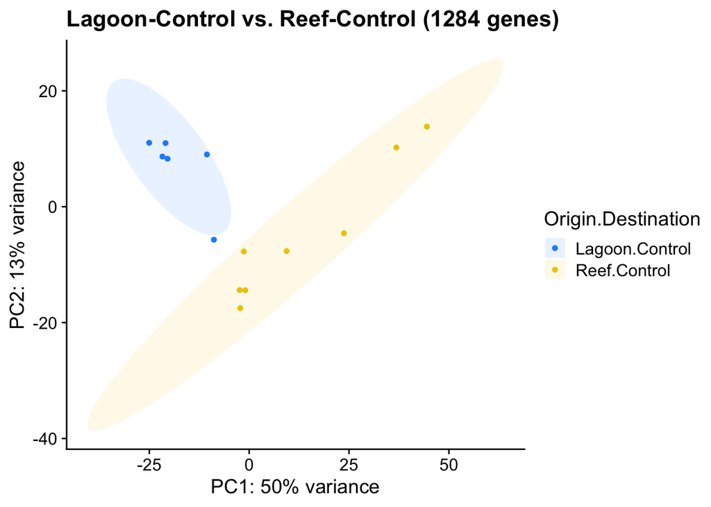

```r
# save plot
#pdf("Sid_Host_PCA_LC_RC_subset.pdf")

pcadata = DESeq2::plotPCA(counts_de, intgroup = c("group"), returnData = TRUE)
percentVar = round(100 * attr(pcadata, "percentVar"))
pca = prcomp(t(assay(counts_de)), center = TRUE, scale. = FALSE)

plot <- DESeq2::plotPCA(counts_de, returnData = TRUE, intgroup = c("group")) %>%
      ggplot(aes(x = PC1, y = PC2)) +
      geom_point(aes(color = group), size = 1.3) +
      stat_ellipse(geom = "polygon", alpha = 1/10, aes(fill = group)) +
      scale_color_manual(values = c("dodgerblue", "gold2", "#163343", "firebrick", "forestgreen", "bisque3")) + #chosen.palette
      scale_fill_manual(values = c("dodgerblue", "gold2", "#163343", "firebrick", "forestgreen", "bisque3")) +
      xlab(paste0("PC1: ",percentVar[1],"% variance")) +
      ylab(paste0("PC2: ",percentVar[2],"% variance")) +
      labs(title = "Lagoon-Control vs. Reef-Control (1284 genes)") +
      labs(color = "Origin.Destination", fill = "Origin.Destination") +
      theme_cowplot()

plot
```

```r
#dev.off()
```

check

```r
dim(counts_de)
```

```
## [1] 1284   14
```

```r
dim(de.genes.LC_RC)
```

```
## [1] 1284    7
```

```r
colnames(counts_de)
```

```
##  [1] "PC_349_C_Sid_yr2" "PC_362_C_Sid_yr2" "PC_365_C_Sid_yr2" "PC_368_C_Sid_yr2"
##  [5] "PC_371_C_Sid_yr2" "PC_374_C_Sid_yr2" "R_003_C_Sid_yr2"  "R_009_C_Sid_yr2"
##  [9] "R_012_C_Sid_yr2"  "R_015_C_Sid_yr2"  "R_021_C_Sid_yr2"  "R_024_C_Sid_yr2"
## [13] "R_027_C_Sid_yr2"  "R_030_C_Sid_yr2"
```

## PCA - all indiv. - OC_RC

```r
# extract row names from DE gene list
rownames(de.genes.OC_RC) <- de.genes.OC_RC[,1]

sigChanges <- rownames(de.genes.OC_RC)[de.genes.OC_RC$pvalue < 0.05 & !is.na(de.genes.OC_RC$pvalue)]

counts_de <- counts.transformed.vst[rownames(counts.transformed.vst) %in% sigChanges,]

dim(counts_de)
```

```
## [1] 1492   37
```

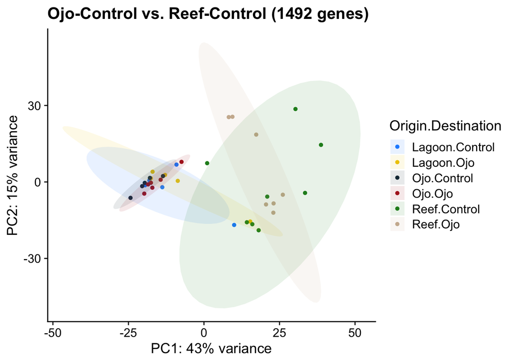

```r
pcadata = DESeq2::plotPCA(counts_de, intgroup = c("group"), returnData = TRUE)
percentVar = round(100 * attr(pcadata, "percentVar"))
pca = prcomp(t(assay(counts_de)), center = TRUE, scale. = FALSE)

plot <- DESeq2::plotPCA(counts_de, returnData = TRUE, intgroup = c("group")) %>%
      ggplot(aes(x = PC1, y = PC2)) +
      geom_point(aes(color = group), size = 1.3) +
      stat_ellipse(geom = "polygon", alpha = 1/10, aes(fill = group)) +
      scale_color_manual(values = c("dodgerblue", "gold2", "#163343", "firebrick", "forestgreen", "bisque3")) + #chosen.palette
      scale_fill_manual(values = c("dodgerblue", "gold2", "#163343", "firebrick", "forestgreen", "bisque3")) +
      xlab(paste0("PC1: ",percentVar[1],"% variance")) +
      ylab(paste0("PC2: ",percentVar[2],"% variance")) +
      labs(title = "Ojo-Control vs. Reef-Control (1492 genes)") +
      labs(color = "Origin.Destination", fill = "Origin.Destination") +
      theme_cowplot()

plot
```

save plot

```r
# save plot
pdf("Sid_Host_PCA_OC_RC_all-indiv.pdf")

pcadata = DESeq2::plotPCA(counts_de, intgroup = c("group"), returnData = TRUE)
percentVar = round(100 * attr(pcadata, "percentVar"))
pca = prcomp(t(assay(counts_de)), center = TRUE, scale. = FALSE)

plot <- DESeq2::plotPCA(counts_de, returnData = TRUE, intgroup = c("group")) %>%
      ggplot(aes(x = PC1, y = PC2)) +
      geom_point(aes(color = group), size = 1.3) +
      stat_ellipse(geom = "polygon", alpha = 1/10, aes(fill = group)) +
      scale_color_manual(values = c("dodgerblue", "gold2", "#163343", "firebrick", "forestgreen", "bisque3")) + #chosen.palette
      scale_fill_manual(values = c("dodgerblue", "gold2", "#163343", "firebrick", "forestgreen", "bisque3")) +
      xlab(paste0("PC1: ",percentVar[1],"% variance")) +
      ylab(paste0("PC2: ",percentVar[2],"% variance")) +
      labs(title = "Ojo-Control vs. Reef-Control (1492 genes)") +
      labs(color = "Origin.Destination", fill = "Origin.Destination") +
      theme_cowplot()

plot

dev.off()
```

## PCA - subset indiv. - OC_RC

```r
# extract row names from DE gene list
rownames(de.genes.OC_RC) <- de.genes.OC_RC[,1]

sigChanges <- rownames(de.genes.OC_RC)[de.genes.OC_RC$pvalue < 0.05 & !is.na(de.genes.OC_RC$pvalue)]

# select relevant sample columns for the given pairwise comparison
colnames(counts.transformed.vst)
```

```
##  [1] "PC_349_C_Sid_yr2"  "PC_350_La_Sid_yr2" "PC_362_C_Sid_yr2"
##  [4] "PC_363_La_Sid_yr2" "PC_365_C_Sid_yr2"  "PC_366_La_Sid_yr2"
##  [7] "PC_368_C_Sid_yr2"  "PC_371_C_Sid_yr2"  "PC_372_La_Sid_yr2"
## [10] "PC_374_C_Sid_yr2"  "PC_375_La_Sid_yr2" "PO_331_C_Sid_yr2"
## [13] "PO_332_La_Sid_yr2" "PO_334_C_Sid_yr2"  "PO_335_La_Sid_yr2"
## [16] "PO_337_C_Sid_yr2"  "PO_338_La_Sid_yr2" "PO_340_C_Sid_yr2"
## [19] "PO_341_La_Sid_yr2" "PO_343_C_Sid_yr2"  "PO_344_La_Sid_yr2"
## [22] "PO_347_La_Sid_yr2" "R_003_C_Sid_yr2"   "R_004_La_Sid_yr2"
## [25] "R_009_C_Sid_yr2"   "R_010_La_Sid_yr2"  "R_012_C_Sid_yr2"
## [28] "R_013_La_Sid_yr2"  "R_015_C_Sid_yr2"   "R_019_La_Sid_yr2"
## [31] "R_021_C_Sid_yr2"   "R_022_La_Sid_yr2"  "R_024_C_Sid_yr2"
## [34] "R_025_La_Sid_yr2"  "R_027_C_Sid_yr2"   "R_030_C_Sid_yr2"
## [37] "R_031_La_Sid_yr2"
```

```r
counts_de <- counts.transformed.vst[,c(12,14,16,18,20,23,25,27,29,31,33,35,36)]

counts_de <- counts_de[rownames(counts.transformed.vst) %in% sigChanges,]

dim(counts_de)
```

```
## [1] 1492   13
```

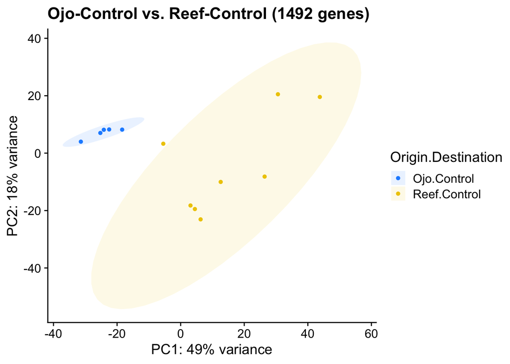

```r
# save plot
#pdf("Sid_Host_PCA_OC_RC_subset.pdf")

pcadata = DESeq2::plotPCA(counts_de, intgroup = c("group"), returnData = TRUE)
percentVar = round(100 * attr(pcadata, "percentVar"))
pca = prcomp(t(assay(counts_de)), center = TRUE, scale. = FALSE)

plot <- DESeq2::plotPCA(counts_de, returnData = TRUE, intgroup = c("group")) %>%
      ggplot(aes(x = PC1, y = PC2)) +
      geom_point(aes(color = group), size = 1.3) +
      stat_ellipse(geom = "polygon", alpha = 1/10, aes(fill = group)) +
      scale_color_manual(values = c("dodgerblue", "gold2", "#163343", "firebrick", "forestgreen", "bisque3")) + #chosen.palette
      scale_fill_manual(values = c("dodgerblue", "gold2", "#163343", "firebrick", "forestgreen", "bisque3")) +
      xlab(paste0("PC1: ",percentVar[1],"% variance")) +
      ylab(paste0("PC2: ",percentVar[2],"% variance")) +
      labs(title = "Ojo-Control vs. Reef-Control (1492 genes)") +
      labs(color = "Origin.Destination", fill = "Origin.Destination") +
      theme_cowplot()

plot
```

```r
#dev.off()
```

check

```r
dim(counts_de)
```

```
## [1] 1492   13
```

```r
dim(de.genes.OC_RC)
```

```
## [1] 1492    7
```

```r
colnames(counts_de)
```

```
##  [1] "PO_331_C_Sid_yr2" "PO_334_C_Sid_yr2" "PO_337_C_Sid_yr2" "PO_340_C_Sid_yr2"
##  [5] "PO_343_C_Sid_yr2" "R_003_C_Sid_yr2"  "R_009_C_Sid_yr2"  "R_012_C_Sid_yr2"
##  [9] "R_015_C_Sid_yr2"  "R_021_C_Sid_yr2"  "R_024_C_Sid_yr2"  "R_027_C_Sid_yr2"
## [13] "R_030_C_Sid_yr2"
```

## PCA - all indiv. - LO_LC

```r
# extract row names from DE gene list
rownames(de.genes.LO_LC) <- de.genes.LO_LC[,1]

sigChanges <- rownames(de.genes.LO_LC)[de.genes.LO_LC$pvalue < 0.05 & !is.na(de.genes.LO_LC$pvalue)]

counts_de <- counts.transformed.vst[rownames(counts.transformed.vst) %in% sigChanges,]

dim(counts_de)
```

```
## [1] 233  37
```

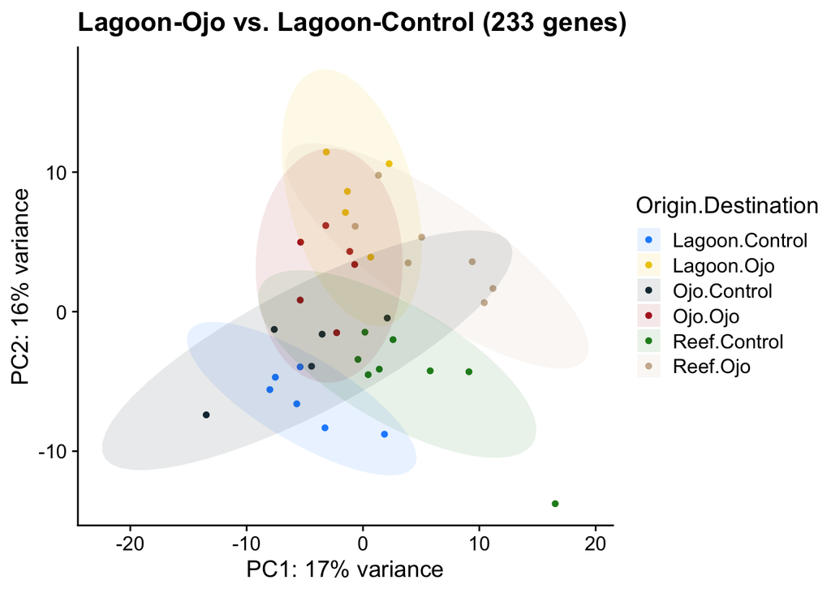

```r
pcadata = DESeq2::plotPCA(counts_de, intgroup = c("group"), returnData = TRUE)
percentVar = round(100 * attr(pcadata, "percentVar"))
pca = prcomp(t(assay(counts_de)), center = TRUE, scale. = FALSE)

plot <- DESeq2::plotPCA(counts_de, returnData = TRUE, intgroup = c("group")) %>%
      ggplot(aes(x = PC1, y = PC2)) +
      geom_point(aes(color = group), size = 1.3) +
      stat_ellipse(geom = "polygon", alpha = 1/10, aes(fill = group)) +
      scale_color_manual(values = c("dodgerblue", "gold2", "#163343", "firebrick", "forestgreen", "bisque3")) + #chosen.palette
      scale_fill_manual(values = c("dodgerblue", "gold2", "#163343", "firebrick", "forestgreen", "bisque3")) +
      xlab(paste0("PC1: ",percentVar[1],"% variance")) +
      ylab(paste0("PC2: ",percentVar[2],"% variance")) +
      labs(title = "Lagoon-Ojo vs. Lagoon-Control (233 genes)") +
      labs(color = "Origin.Destination", fill = "Origin.Destination") +
      theme_cowplot()

plot
```

save plot

```r
# save plot
pdf("Sid_Host_PCA_LO_LC_all-indiv.pdf")

pcadata = DESeq2::plotPCA(counts_de, intgroup = c("group"), returnData = TRUE)
percentVar = round(100 * attr(pcadata, "percentVar"))
pca = prcomp(t(assay(counts_de)), center = TRUE, scale. = FALSE)

plot <- DESeq2::plotPCA(counts_de, returnData = TRUE, intgroup = c("group")) %>%
      ggplot(aes(x = PC1, y = PC2)) +
      geom_point(aes(color = group), size = 1.3) +
      stat_ellipse(geom = "polygon", alpha = 1/10, aes(fill = group)) +
      scale_color_manual(values = c("dodgerblue", "gold2", "#163343", "firebrick", "forestgreen", "bisque3")) + #chosen.palette
      scale_fill_manual(values = c("dodgerblue", "gold2", "#163343", "firebrick", "forestgreen", "bisque3")) +
      xlab(paste0("PC1: ",percentVar[1],"% variance")) +
      ylab(paste0("PC2: ",percentVar[2],"% variance")) +
      labs(title = "Lagoon-Ojo vs. Lagoon-Control (233 genes)") +
      labs(color = "Origin.Destination", fill = "Origin.Destination") +
      theme_cowplot()

plot

dev.off()
```

## PCA - subset indiv. - LO_LC

```r
# extract row names from DE gene list
rownames(de.genes.LO_LC) <- de.genes.LO_LC[,1]

sigChanges <- rownames(de.genes.LO_LC)[de.genes.LO_LC$pvalue < 0.05 & !is.na(de.genes.LO_LC$pvalue)]

# select relevant sample columns for the given pairwise comparison
colnames(counts.transformed.vst)
```

```
##  [1] "PC_349_C_Sid_yr2"  "PC_350_La_Sid_yr2" "PC_362_C_Sid_yr2"
##  [4] "PC_363_La_Sid_yr2" "PC_365_C_Sid_yr2"  "PC_366_La_Sid_yr2"
##  [7] "PC_368_C_Sid_yr2"  "PC_371_C_Sid_yr2"  "PC_372_La_Sid_yr2"
## [10] "PC_374_C_Sid_yr2"  "PC_375_La_Sid_yr2" "PO_331_C_Sid_yr2"
## [13] "PO_332_La_Sid_yr2" "PO_334_C_Sid_yr2"  "PO_335_La_Sid_yr2"
## [16] "PO_337_C_Sid_yr2"  "PO_338_La_Sid_yr2" "PO_340_C_Sid_yr2"
## [19] "PO_341_La_Sid_yr2" "PO_343_C_Sid_yr2"  "PO_344_La_Sid_yr2"
## [22] "PO_347_La_Sid_yr2" "R_003_C_Sid_yr2"   "R_004_La_Sid_yr2"
## [25] "R_009_C_Sid_yr2"   "R_010_La_Sid_yr2"  "R_012_C_Sid_yr2"
## [28] "R_013_La_Sid_yr2"  "R_015_C_Sid_yr2"   "R_019_La_Sid_yr2"
## [31] "R_021_C_Sid_yr2"   "R_022_La_Sid_yr2"  "R_024_C_Sid_yr2"
## [34] "R_025_La_Sid_yr2"  "R_027_C_Sid_yr2"   "R_030_C_Sid_yr2"
## [37] "R_031_La_Sid_yr2"
```

```r
counts_de <- counts.transformed.vst[,c(1:11)]

counts_de <- counts_de[rownames(counts.transformed.vst) %in% sigChanges,]

dim(counts_de)
```

```
## [1] 233  11
```

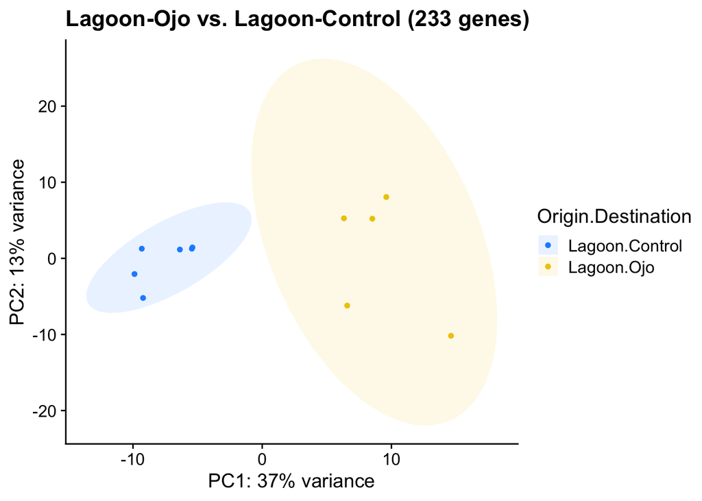

```r
# save plot
#pdf("Sid_Host_PCA_LO_LC_subset.pdf")

pcadata = DESeq2::plotPCA(counts_de, intgroup = c("group"), returnData = TRUE)
percentVar = round(100 * attr(pcadata, "percentVar"))
pca = prcomp(t(assay(counts_de)), center = TRUE, scale. = FALSE)

plot <- DESeq2::plotPCA(counts_de, returnData = TRUE, intgroup = c("group")) %>%
      ggplot(aes(x = PC1, y = PC2)) +
      geom_point(aes(color = group), size = 1.3) +
      stat_ellipse(geom = "polygon", alpha = 1/10, aes(fill = group)) +
      scale_color_manual(values = c("dodgerblue", "gold2", "#163343", "firebrick", "forestgreen", "bisque3")) + #chosen.palette
      scale_fill_manual(values = c("dodgerblue", "gold2", "#163343", "firebrick", "forestgreen", "bisque3")) +
      xlab(paste0("PC1: ",percentVar[1],"% variance")) +
      ylab(paste0("PC2: ",percentVar[2],"% variance")) +
      labs(title = "Lagoon-Ojo vs. Lagoon-Control (233 genes)") +
      labs(color = "Origin.Destination", fill = "Origin.Destination") +
      theme_cowplot()

plot
```

```r
#dev.off()
```

check

```r
dim(counts_de)
```

```
## [1] 233  11
```

```r
dim(de.genes.LO_LC)
```

```
## [1] 233   7
```

```r
colnames(counts_de)
```

```
##  [1] "PC_349_C_Sid_yr2"  "PC_350_La_Sid_yr2" "PC_362_C_Sid_yr2"
##  [4] "PC_363_La_Sid_yr2" "PC_365_C_Sid_yr2"  "PC_366_La_Sid_yr2"
##  [7] "PC_368_C_Sid_yr2"  "PC_371_C_Sid_yr2"  "PC_372_La_Sid_yr2"
## [10] "PC_374_C_Sid_yr2"  "PC_375_La_Sid_yr2"
```

# PERMANOVA

### transpose gene table

```r
norm.genes.t <- data.table::transpose(norm.genes, keep.names = "rn")

rownames(norm.genes.t) <- norm.genes.t[,1]

norm.genes.t <- norm.genes.t[,-1]

dim(norm.genes.t)
```

```
## [1]   37 8000
```

### Make distance matrix

```r
dist_overall <- vegdist(norm.genes.t, method="bray")
```

## PERMANOVA - Total gene expression (normalized)

```r
permanova_overall.interaction <- adonis(dist_overall ~ Origin_name + Destination_name + Origin_name*Destination_name, data = meta, permutations=9999, na.rm = TRUE)
permanova_overall.interaction
```

```
##
## Call:
## adonis(formula = dist_overall ~ Origin_name + Destination_name +      Origin_name * Destination_name, data = meta, permutations = 9999,      na.rm = TRUE)
##
## Permutation: free
## Number of permutations: 9999
##
## Terms added sequentially (first to last)
##
##                              Df SumsOfSqs  MeanSqs F.Model      R2 Pr(>F)
## Origin_name                   2   0.39386 0.196932 2.71898 0.13721 0.0070 **
## Destination_name              1   0.09384 0.093839 1.29561 0.03269 0.2288
## Origin_name:Destination_name  2   0.13751 0.068755 0.94928 0.04790 0.4565
## Residuals                    31   2.24529 0.072429         0.78219
## Total                        36   2.87050                  1.00000
## ---
## Signif. codes:  0 '***' 0.001 '**' 0.01 '*' 0.05 '.' 0.1 ' ' 1
```

(Alternate) Make distance matrix and run PERMANOVA together in *one function* adonis(norm.genes.t ~ group, data = meta, method = “bray”, permutations=9999, na.rm = TRUE)

## Pairwise PERMANOVA

This is a wrapper function for multilevel pairwise comparison using adonis() from package ‘vegan’. The function returns adjusted p-values using p.adjust(), default is ‘bonferroni’. - ‘arg’ should be one of “holm”, “hochberg”, “hommel”, “bonferroni”, “BH”, “BY”, “fdr”, “none”

## Pairwise PERMANOVA - Origin

```r
pairwise.adonis(dist_overall, factors = meta$Origin_type,  p.adjust.m = 'fdr', perm = 9999)
```

```
##            pairs Df  SumsOfSqs   F.Model         R2 p.value p.adjusted sig
## 1  Lagoon vs Ojo  1 0.03069854 0.5213376 0.02540466  0.8759    0.87590
## 2 Lagoon vs Reef  1 0.27355308 3.5756921 0.12966826  0.0122    0.02295   .
## 3    Ojo vs Reef  1 0.26096899 3.2293099 0.11859683  0.0153    0.02295   .
```

```r
# sim.function = 'vegdist' (default)
# sim.method = 'bray' (default)
## calculate the similarity matrix. Ignored if x is a distance matrix)
```

## Pairwise PERMANOVA - Group

```r
pairwise.adonis(dist_overall, factors = meta$group,  p.adjust.m = 'fdr', perm = 9999)
```

```
##                             pairs Df  SumsOfSqs   F.Model         R2 p.value
## 1    Lagoon.Control vs Lagoon.Ojo  1 0.03292935 0.5877869 0.06130579  0.6415
## 2   Lagoon.Control vs Ojo.Control  1 0.01131196 0.4125764 0.04383246  0.8301
## 3       Lagoon.Control vs Ojo.Ojo  1 0.04521794 0.6594531 0.06186556  0.8758
## 4  Lagoon.Control vs Reef.Control  1 0.07750582 1.4730148 0.10933075  0.2015
## 5      Lagoon.Control vs Reef.Ojo  1 0.24294430 2.9784454 0.21307415  0.0506
## 6       Lagoon.Ojo vs Ojo.Control  1 0.06016443 1.2311210 0.13336636  0.2748
## 7           Lagoon.Ojo vs Ojo.Ojo  1 0.04709939 0.5107870 0.05370607  0.9171
## 8      Lagoon.Ojo vs Reef.Control  1 0.12618391 1.7896071 0.13992667  0.1395
## 9          Lagoon.Ojo vs Reef.Ojo  1 0.26299947 2.5253473 0.20161895  0.0695
## 10         Ojo.Control vs Ojo.Ojo  1 0.06810853 1.0708099 0.10632808  0.3629
## 11    Ojo.Control vs Reef.Control  1 0.06230704 1.3227158 0.10733963  0.2506
## 12        Ojo.Control vs Reef.Ojo  1 0.19789834 2.5242264 0.20154749  0.0972
## 13        Ojo.Ojo vs Reef.Control  1 0.14405725 1.8061958 0.13082502  0.0849
## 14            Ojo.Ojo vs Reef.Ojo  1 0.31066692 2.7943979 0.20257484  0.0311
```

[output cut: 17 more lines]

```r
# sim.function = 'vegdist' (default)
# sim.method = 'bray' (default)
## calculate the similarity matrix. Ignored if x is a distance matrix)
```

**pairwise.adonis() does not accept interaction between factors neither strata.**

# pairwise.adonis2()

This function accepts strata

NOTE: This is still a developing version – results using interactions may not be right. Please validate. I would appreciate feed back.

update 28 April 2020: Function now adapts the permutation matrix for each combination of factors before applying adonis. The p-value when using strata (block) looks correct now. Check syntax in example below.

This function accepts a model formula like in adonis from vegan. You can use interactions between factors and define strata to constrain permutations. For pairwise comparison a list of unique pairwise combination of factors is produced. Then for each pair, following objects are reduced accordingly to include only the subset of cases belonging to the pair:

```
the left hand side of the formula (dissimilarity matrix or community matrix)

the right hand side of the formula (factors)

the strata if used.
```

The reduced data are passed to adonis and the summary of the anova table for each pair is saved in a list, together with the anova table of the full model and the original ‘parent call’.

https://github.com/pmartinezarbizu/pairwiseAdonis

```r
pairwise.adonis2(dist_overall ~ Origin_type * Destination_type, data = meta, perm = 9999)
```

```
## $parent_call
## [1] "dist_overall ~ Origin_type * Destination_type , strata = Null"
##
## $Lagoon_vs_Ojo
## Permutation: free
## Number of permutations: 9999
##
## Terms added sequentially (first to last)
##
##                              Df SumsOfSqs  MeanSqs F.Model      R2 Pr(>F)
## Origin_type                   1   0.03070 0.030699 0.51324 0.02540 0.8834
## Destination_type              1   0.07468 0.074684 1.24861 0.06180 0.2483
## Origin_type:Destination_type  1   0.02635 0.026354 0.44060 0.02181 0.9465
## Residuals                    18   1.07665 0.059814         0.89098
## Total                        21   1.20838                  1.00000
##
## $Lagoon_vs_Reef
## Permutation: free
## Number of permutations: 9999
##
## Terms added sequentially (first to last)
##
##                              Df SumsOfSqs  MeanSqs F.Model      R2 Pr(>F)
## Origin_type                   1   0.27355 0.273553  3.5976 0.12967 0.0140 *
## Destination_type              1   0.09461 0.094608  1.2442 0.04485 0.2601
## Origin_type:Destination_type  1   0.06863 0.068633  0.9026 0.03253 0.4294
## Residuals                    22   1.67284 0.076038         0.79295
## Total                        25   2.10964                  1.00000
## ---
## Signif. codes:  0 '***' 0.001 '**' 0.01 '*' 0.05 '.' 0.1 ' ' 1
##
## $Ojo_vs_Reef
## Permutation: free
## Number of permutations: 9999
##
## Terms added sequentially (first to last)
##
##                              Df SumsOfSqs  MeanSqs F.Model      R2 Pr(>F)
## Origin_type                   1   0.26097 0.260969  3.2976 0.11860 0.0138 *
## Destination_type              1   0.09374 0.093744  1.1845 0.04260 0.2690
## Origin_type:Destination_type  1   0.10468 0.104675  1.3227 0.04757 0.2191
## Residuals                    22   1.74108 0.079140         0.79123
## Total                        25   2.20047                  1.00000
## ---
## Signif. codes:  0 '***' 0.001 '**' 0.01 '*' 0.05 '.' 0.1 ' ' 1
##
## attr(,"class")
## [1] "pwadstrata" "list"
```